# EVOS Oyster Morphometrics - Farm Report

AOF1

December 2025

### **By Farm**

Most farms saw increases in average shell height from summer 2025 to fall 2025. All farms saw increases in average meat weight from summer 2025 to fall 2025. Cup ratio is calculated by dividing shell depth by shell height. A higher value is a thicker oyster relative to height. Although there are no universally accepted thresholds for shell shapes, the generally accepted shell quality threshold is 0.25 for cup ratio (Brake et al., 2003; Mizuta and Wikfors, 2019). The range of cup ratios across farms at the fall 2025 sample event was 0.28 to 0.35.

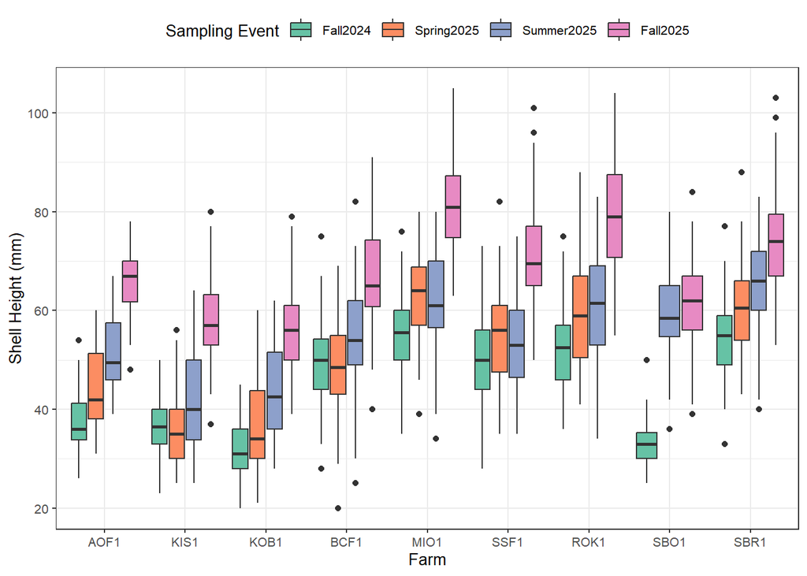

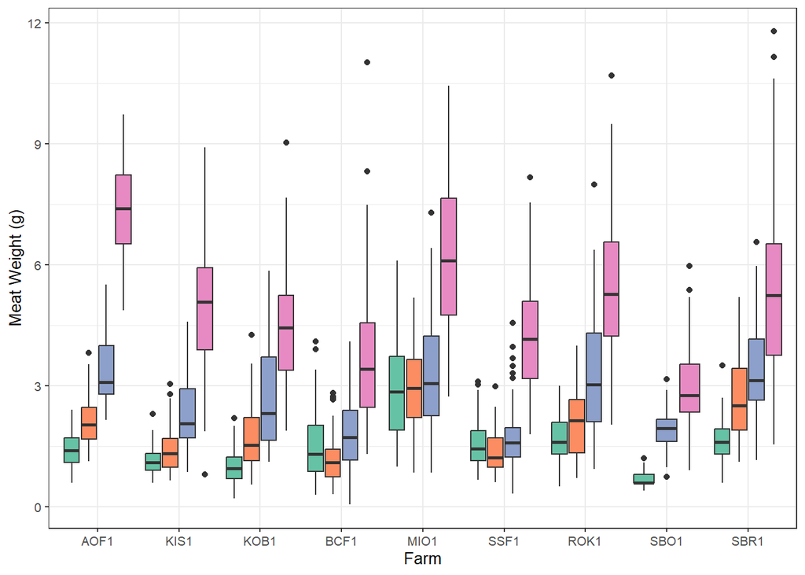

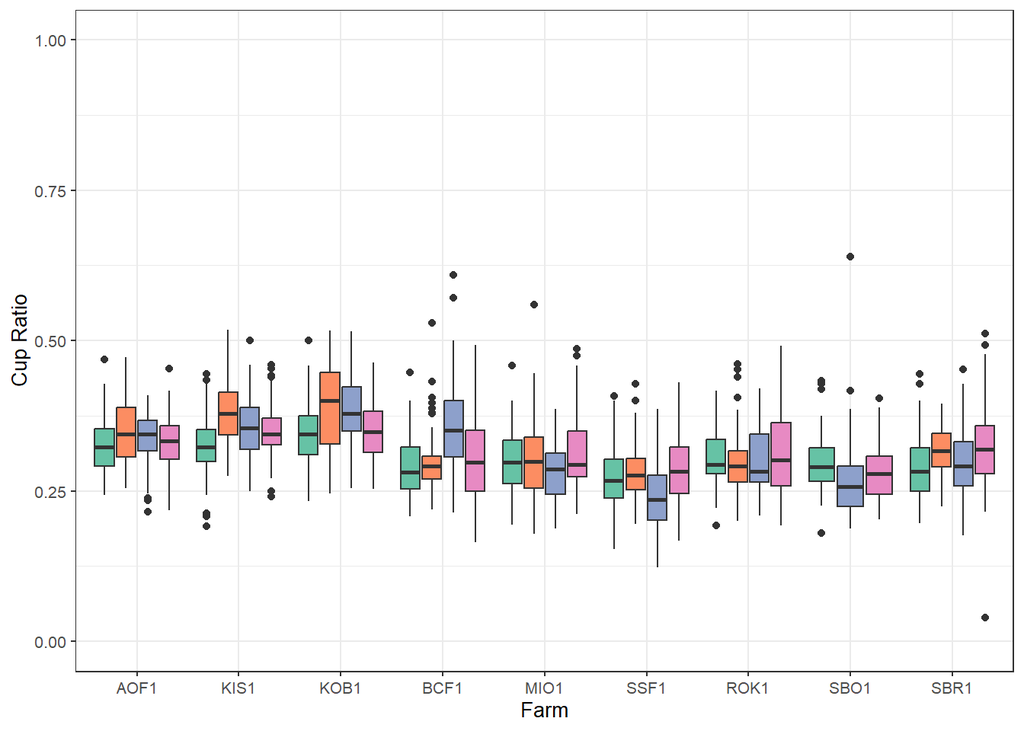

### **By Region**

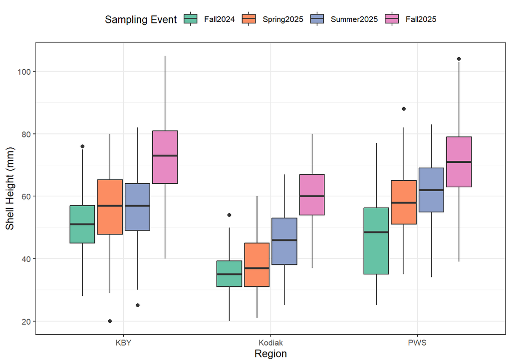

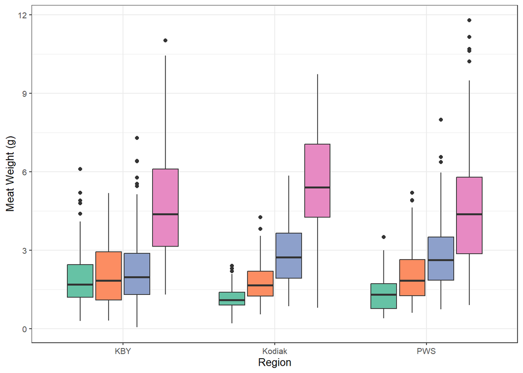

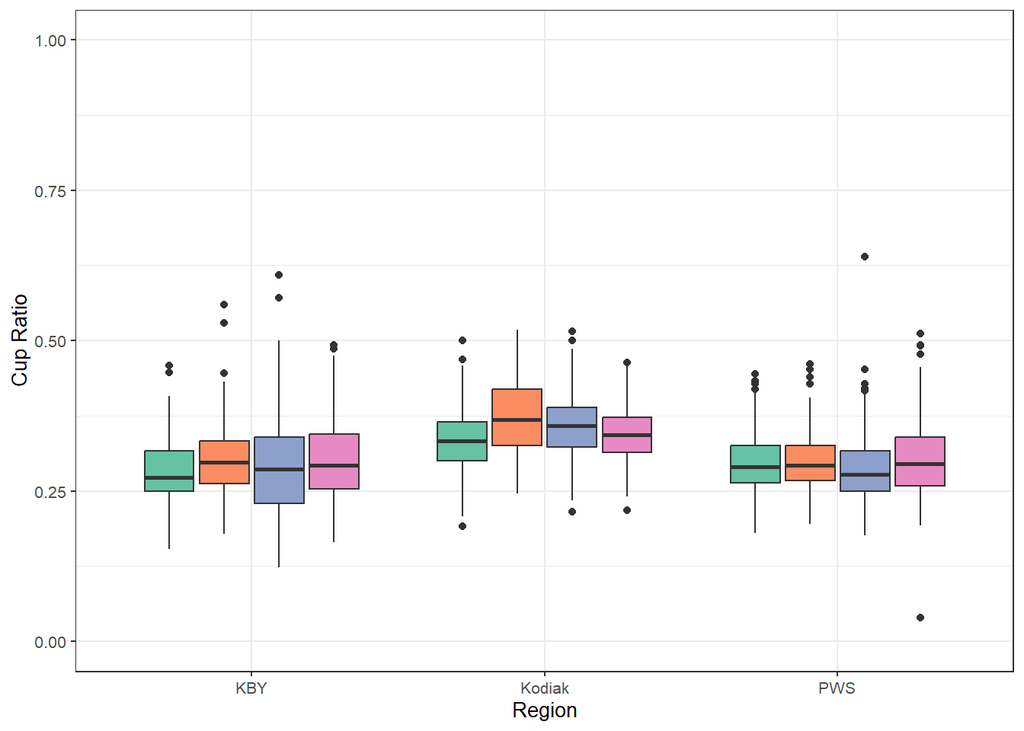

### **AOF1**

Average shell height (mm) in fall 2025 was 65.60 and average meat weight (g) was 7.34. Average cup ratio in fall 2025 was 0.3348851.

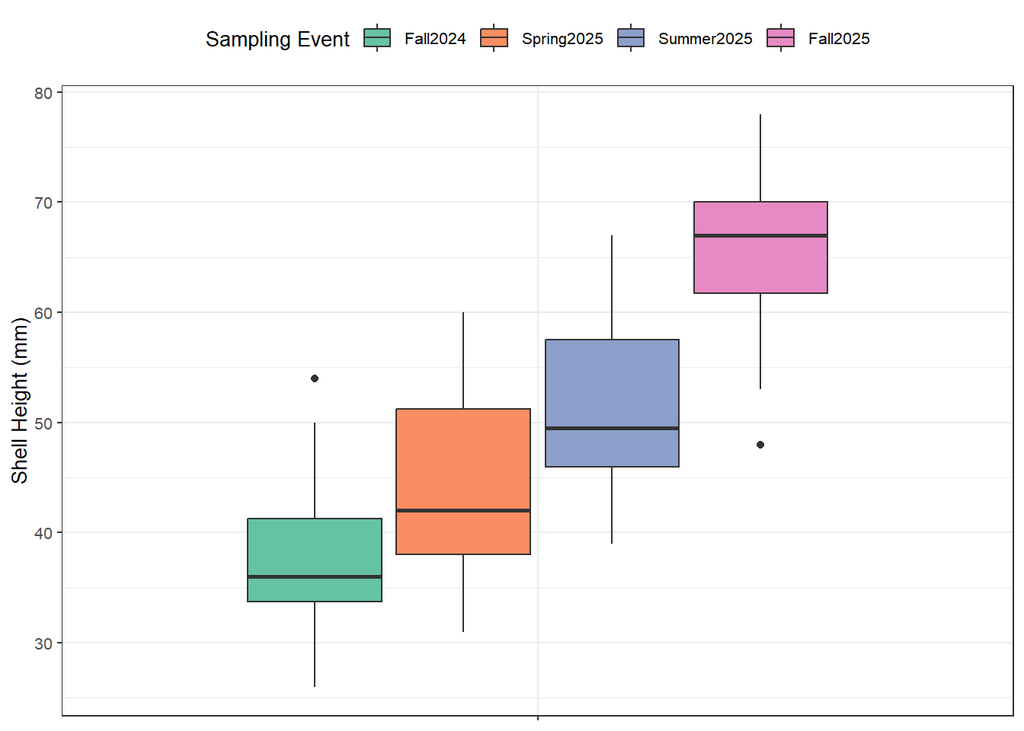

[figure not shown]

[figure not shown]